# ADP Practice 2

Ku, Bonseong

2020 12 6

## 데이터, 패키지 로드

```r
set.seed(12345)
library(corrplot)
library(lmtest)
library(DMwR)
library(rpart)
library(rpart.plot)
library(randomForest)
library(e1071)
library(ROCR)
library(caret)
library(tm)
library(rJava)
library(KoNLP)
library(wordcloud)
library(plyr)
library(dplyr)

adm<-read.csv('Admission.csv') #통계분석
titan<-read.csv("titanic.csv") #정형 데이터마이닝
moon<-readLines("연설문.txt")
```

## 통계분석

```r
str(adm)
```

```
## 'data.frame':    400 obs. of  8 variables:
##  $ GRE            : int  337 324 316 322 314 330 321 308 302 323 ...
##  $ TOEFL          : int  118 107 104 110 103 115 109 101 102 108 ...
##  $ Univ_Rating    : int  4 4 3 3 2 5 3 2 1 3 ...
##  $ SOP            : num  4.5 4 3 3.5 2 4.5 3 3 2 3.5 ...
##  $ LOR            : num  4.5 4.5 3.5 2.5 3 3 4 4 1.5 3 ...
##  $ CGPA           : num  9.65 8.87 8 8.67 8.21 9.34 8.2 7.9 8 8.6 ...
##  $ Research       : int  1 1 1 1 0 1 1 0 0 0 ...
##  $ Chance_of_Admit: num  0.92 0.76 0.72 0.8 0.65 0.9 0.75 0.68 0.5 0.45 ...
```

```r
sum(is.na(adm)) # 결측치 없음
```

```
## [1] 0
```

### 상관분석

```r
cor(adm[-6])
```

```
##                       GRE     TOEFL Univ_Rating       SOP       LOR
## GRE             1.0000000 0.8359768   0.6689759 0.6128307 0.5575545
## TOEFL           0.8359768 1.0000000   0.6955898 0.6579805 0.5677209
## Univ_Rating     0.6689759 0.6955898   1.0000000 0.7345228 0.6601235
## SOP             0.6128307 0.6579805   0.7345228 1.0000000 0.7295925
## LOR             0.5575545 0.5677209   0.6601235 0.7295925 1.0000000
## Research        0.5803906 0.4898579   0.4477825 0.4440288 0.3968593
## Chance_of_Admit 0.8026105 0.7915940   0.7112503 0.6757319 0.6698888
##                  Research Chance_of_Admit
## GRE             0.5803906       0.8026105
## TOEFL           0.4898579       0.7915940
## Univ_Rating     0.4477825       0.7112503
## SOP             0.4440288       0.6757319
## LOR             0.3968593       0.6698888
## Research        1.0000000       0.5532021
## Chance_of_Admit 0.5532021       1.0000000
```

```r
cor.test(adm$Chance_of_Admit, adm$GRE)
```

```
##
##  Pearson's product-moment correlation
##
## data:  adm$Chance_of_Admit and adm$GRE
## t = 26.843, df = 398, p-value < 2.2e-16
## alternative hypothesis: true correlation is not equal to 0
## 95 percent confidence interval:
##  0.7647419 0.8349536
## sample estimates:
##       cor
## 0.8026105
```

- 입학 허가 확률과 GRE 점수는 0.8의 상관계수를 지니고 있다.
- p-value<0.05 이므로 상관계수는 유의하다

```r
#cor.test(adm$Chance_of_Admit, adm$TOEFL)
#cor.test(adm$Chance_of_Admit, adm$Univ_Rating)
#cor.test(adm$Chance_of_Admit, adm$SOP)
#cor.test(adm$Chance_of_Admit, adm$LOR)
#cor.test(adm$Chance_of_Admit, adm$CGPA)
```

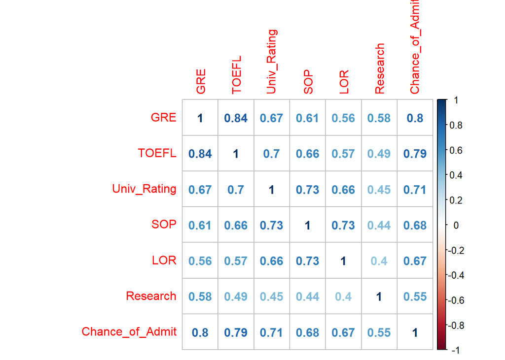

```r
corrplot(cor(adm[,-6]),method="number")
```

```r
adm_lm<-lm(Chance_of_Admit~.,data=adm)
summary(adm_lm)
```

```
##
## Call:
## lm(formula = Chance_of_Admit ~ ., data = adm)
##
## Residuals:
##      Min       1Q   Median       3Q      Max
## -0.26259 -0.02103  0.01005  0.03628  0.15928
##
## Coefficients:
##               Estimate Std. Error t value Pr(>|t|)
## (Intercept) -1.2594325  0.1247307 -10.097  < 2e-16 ***
## GRE          0.0017374  0.0005979   2.906  0.00387 **
## TOEFL        0.0029196  0.0010895   2.680  0.00768 **
## Univ_Rating  0.0057167  0.0047704   1.198  0.23150
## SOP         -0.0033052  0.0055616  -0.594  0.55267
## LOR          0.0223531  0.0055415   4.034  6.6e-05 ***
## CGPA         0.1189395  0.0122194   9.734  < 2e-16 ***
## Research     0.0245251  0.0079598   3.081  0.00221 **
## ---
## Signif. codes:  0 '***' 0.001 '**' 0.01 '*' 0.05 '.' 0.1 ' ' 1
##
## Residual standard error: 0.06378 on 392 degrees of freedom
## Multiple R-squared:  0.8035, Adjusted R-squared:    0.8
## F-statistic: 228.9 on 7 and 392 DF,  p-value: < 2.2e-16
```

```r
step(adm_lm, direction='both')
```

```
## Start:  AIC=-2193.9
## Chance_of_Admit ~ GRE + TOEFL + Univ_Rating + SOP + LOR + CGPA +
##     Research
##
##               Df Sum of Sq    RSS     AIC
## - SOP          1   0.00144 1.5962 -2195.5
## - Univ_Rating  1   0.00584 1.6006 -2194.4
## <none>                     1.5948 -2193.9
## - TOEFL        1   0.02921 1.6240 -2188.6
## - GRE          1   0.03435 1.6291 -2187.4
## - Research     1   0.03862 1.6334 -2186.3
## - LOR          1   0.06620 1.6609 -2179.6
## - CGPA         1   0.38544 1.9802 -2109.3
##
## Step:  AIC=-2195.54
## Chance_of_Admit ~ GRE + TOEFL + Univ_Rating + LOR + CGPA + Research
##
##               Df Sum of Sq    RSS     AIC
## - Univ_Rating  1   0.00464 1.6008 -2196.4
## <none>                     1.5962 -2195.5
## + SOP          1   0.00144 1.5948 -2193.9
## - TOEFL        1   0.02806 1.6242 -2190.6
## - GRE          1   0.03565 1.6318 -2188.7
## - Research     1   0.03769 1.6339 -2188.2
## - LOR          1   0.06983 1.6660 -2180.4
## - CGPA         1   0.38660 1.9828 -2110.8
##
## Step:  AIC=-2196.38
## Chance_of_Admit ~ GRE + TOEFL + LOR + CGPA + Research
##
##               Df Sum of Sq    RSS     AIC
## <none>                     1.6008 -2196.4
## + Univ_Rating  1   0.00464 1.5962 -2195.5
## + SOP          1   0.00024 1.6006 -2194.4
## - TOEFL        1   0.03292 1.6338 -2190.2
## - GRE          1   0.03638 1.6372 -2189.4
## - Research     1   0.03912 1.6400 -2188.7
## - LOR          1   0.09133 1.6922 -2176.2
## - CGPA         1   0.43201 2.0328 -2102.8
```

```
##
## Call:
## lm(formula = Chance_of_Admit ~ GRE + TOEFL + LOR + CGPA + Research,
##     data = adm)
##
## Coefficients:
## (Intercept)          GRE        TOEFL          LOR         CGPA
##   -1.298464     0.001782     0.003032     0.022776     0.121004
##    Research
##    0.024577
```

- 이후 단계적 선택법을 통해 변수를 선택한다.
- 첫 단계에서는 SOP 변수를 제거했을 때, AIC가 가장 낮은 것을 확인할 수 있다. 이와 같은 방법으로 AIC을 낮추는 방향으로 변수를 추가, 제거함으로써 가장 설명력이 높은 회귀모형을 선택한다. -최종적으로 GRE TOEFL LOR GCPA Research 변수를 선택한다.

```r
adm_lm2<-lm(Chance_of_Admit ~ GRE + TOEFL + LOR + CGPA + Research, data = adm)
summary(adm_lm2)
```

```
##
## Call:
## lm(formula = Chance_of_Admit ~ GRE + TOEFL + LOR + CGPA + Research,
##     data = adm)
##
## Residuals:
##       Min        1Q    Median        3Q       Max
## -0.263542 -0.023297  0.009879  0.038078  0.159897
##
## Coefficients:
##               Estimate Std. Error t value Pr(>|t|)
## (Intercept) -1.2984636  0.1172905 -11.070  < 2e-16 ***
## GRE          0.0017820  0.0005955   2.992  0.00294 **
## TOEFL        0.0030320  0.0010651   2.847  0.00465 **
## LOR          0.0227762  0.0048039   4.741 2.97e-06 ***
## CGPA         0.1210042  0.0117349  10.312  < 2e-16 ***
## Research     0.0245769  0.0079203   3.103  0.00205 **
## ---
## Signif. codes:  0 '***' 0.001 '**' 0.01 '*' 0.05 '.' 0.1 ' ' 1
##
## Residual standard error: 0.06374 on 394 degrees of freedom
## Multiple R-squared:  0.8027, Adjusted R-squared:  0.8002
## F-statistic: 320.6 on 5 and 394 DF,  p-value: < 2.2e-16
```

### 잔차분석

#### 독립성 검정

```r
dwtest(adm_lm2)
```

```
##
##  Durbin-Watson test
##
## data:  adm_lm2
## DW = 0.74991, p-value < 2.2e-16
## alternative hypothesis: true autocorrelation is greater than 0
```

- 더빈왓슨 검정은 잔차에 대한 독립성을 검정한다.
- DW 통계량이 0에 가깝다면 양의 자기상관이 있으며,
- 2에 가깝다면 자기상관이 거의 없고,
- 4에 가깝다면 음의 자기상관이 있음을 알 수 있다.
- DW = 0.74991 로서 0에 가까우며, p-value < 0.05이므로 DW의 값에 따라 독립성 가정을 만족한다고 보기 어렵다.

#### 정규성 가정

```r
shapiro.test(resid(adm_lm2))
```

```
##
##  Shapiro-Wilk normality test
##
## data:  resid(adm_lm2)
## W = 0.92193, p-value = 1.443e-13
```

- 샤피로 윌크 검정은 데이터 정규성을 가지는지에 대한 검정이다.
- 이때 귀무가설은 주어진 데이터가 정규분포로부터의 표본이라는 것이다.
- p-value < 0.05 이므로 귀무가설을 기각한다. 따라서 정규성을 만족한다고 보기 어렵다.

#### 등분산성 검정

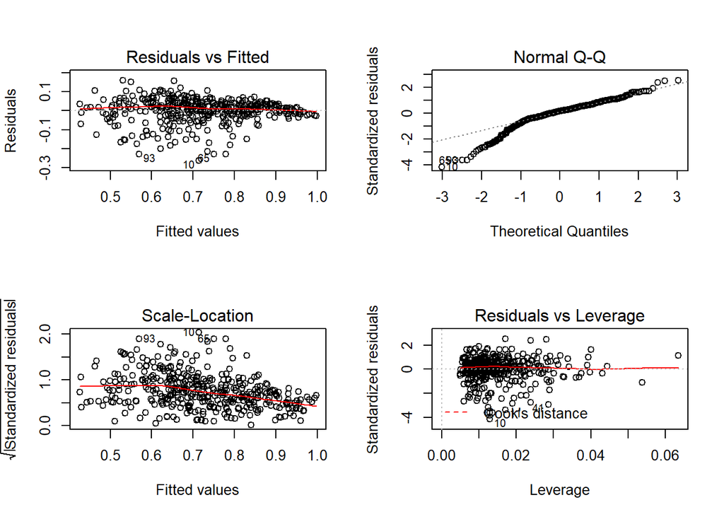

```r
par(mfrow=c(2,2))
plot(adm_lm2)
```

- 좌측 윗그림은 잔차 vs 예측된 y값에 대한 분포이다. 그래프의 기울기를 나타내는 빨간색 선이 직선의 성향을 띄고 있기 때문에, 잔차는 평균이 0을 중심으로 고르게 분포함을 알 수 있다.
- 우측 윗그림은 Q-Q Plot이다. 점선위에 점이 있다면 정규성을 만족한다고 하는데, 그림은 그렇지 않다. 따라서 정규성이 위배되는 것처럼 보인다.
- Scale-Location은 등분산성 가정을 확인한다. 빨간선의 기울기가 x축과 거의 평행해야하지만, Fitted Values가 커질수록 감소하는 추세이다. 따라서 회귀직선이 y값을 잘 적합하지 못함을 알 수 있다.

## 정형 데이터 마이닝

```r
summary(titan)
```

```
##      pclass         survived                                   name
##  Min.   :1.000   Min.   :0.000   Connolly, Miss. Kate            :   2
##  1st Qu.:2.000   1st Qu.:0.000   Kelly, Mr. James                :   2
##  Median :3.000   Median :0.000   Abbing, Mr. Anthony             :   1
##  Mean   :2.295   Mean   :0.382   Abbott, Master. Eugene Joseph   :   1
##  3rd Qu.:3.000   3rd Qu.:1.000   Abbott, Mr. Rossmore Edward     :   1
##  Max.   :3.000   Max.   :1.000   Abbott, Mrs. Stanton (Rosa Hunt):   1
##                                  (Other)                         :1301
##      sex           age            sibsp            parch
##  female:466   Min.   : 0.17   Min.   :0.0000   Min.   :0.000
##  male  :843   1st Qu.:21.00   1st Qu.:0.0000   1st Qu.:0.000
##               Median :28.00   Median :0.0000   Median :0.000
##               Mean   :29.88   Mean   :0.4989   Mean   :0.385
##               3rd Qu.:39.00   3rd Qu.:1.0000   3rd Qu.:0.000
##               Max.   :80.00   Max.   :8.0000   Max.   :9.000
##               NA's   :263
##       ticket          fare                     cabin      embarked
##  CA. 2343:  11   Min.   :  0.000                  :1014    :  2
##  1601    :   8   1st Qu.:  7.896   C23 C25 C27    :   6   C:270
##  CA 2144 :   8   Median : 14.454   B57 B59 B63 B66:   5   Q:123
##  3101295 :   7   Mean   : 33.295   G6             :   5   S:914
##  347077  :   7   3rd Qu.: 31.275   B96 B98        :   4
##  347082  :   7   Max.   :512.329   C22 C26        :   4
##  (Other) :1261   NA's   :1         (Other)        : 271
```

```r
levels(titan$embarked)[1]<-NA # 결측치 처리
table(titan$embarked,useNA="always") #useNA="always"는 NA 개수도 출력
```

```
##
##    C    Q    S <NA>
##  270  123  914    2
```

```r
titan$cabin<-ifelse(titan$cabin=="",NA,titan$cabin)
```

```r
str(titan) # 데이터 형식 변환
```

```
## 'data.frame':    1309 obs. of  11 variables:
##  $ pclass  : int  1 1 1 1 1 1 1 1 1 1 ...
##  $ survived: int  1 1 0 0 0 1 1 0 1 0 ...
##  $ name    : Factor w/ 1307 levels "Abbing, Mr. Anthony",..: 22 24 25 26 27 31 46 47 51 55 ...
##  $ sex     : Factor w/ 2 levels "female","male": 1 2 1 2 1 2 1 2 1 2 ...
##  $ age     : num  29 0.92 2 30 25 48 63 39 53 71 ...
##  $ sibsp   : int  0 1 1 1 1 0 1 0 2 0 ...
##  $ parch   : int  0 2 2 2 2 0 0 0 0 0 ...
##  $ ticket  : Factor w/ 929 levels "110152","110413",..: 188 50 50 50 50 125 93 16 77 826 ...
##  $ fare    : num  211 152 152 152 152 ...
##  $ cabin   : int  45 81 81 81 81 151 147 17 63 NA ...
##  $ embarked: Factor w/ 3 levels "C","Q","S": 3 3 3 3 3 3 3 3 3 1 ...
```

```r
titan$pclass<-as.factor(titan$pclass)
titan$name<-as.character(titan$name)
titan$ticket<-as.character(titan$ticket)
titan$cabin<-as.character(titan$cabin)
titan$survived<-factor(titan$survived,levels=c(0,1),labels=c("dead","survived"))
```

```r
sum(complete.cases(titan)) #결측치 대체
```

```
## [1] 270
```

```r
titan2<-centralImputation(titan)
summary(titan2)
```

```
##  pclass      survived       name               sex           age
##  1:323   dead    :809   Length:1309        female:466   Min.   : 0.17
##  2:277   survived:500   Class :character   male  :843   1st Qu.:22.00
##  3:709                  Mode  :character                Median :28.00
##                                                         Mean   :29.50
##                                                         3rd Qu.:35.00
##                                                         Max.   :80.00
##      sibsp            parch          ticket               fare
##  Min.   :0.0000   Min.   :0.000   Length:1309        Min.   :  0.000
##  1st Qu.:0.0000   1st Qu.:0.000   Class :character   1st Qu.:  7.896
##  Median :0.0000   Median :0.000   Mode  :character   Median : 14.454
##  Mean   :0.4989   Mean   :0.385                      Mean   : 33.281
##  3rd Qu.:1.0000   3rd Qu.:0.000                      3rd Qu.: 31.275
##  Max.   :8.0000   Max.   :9.000                      Max.   :512.329
##     cabin           embarked
##  Length:1309        C:270
##  Class :character   Q:123
##  Mode  :character   S:916
##
##
##
```

```r
sum(is.na(titan2))
```

```
## [1] 0
```

```r
titan2<-within(titan2,
                 {
                   age_1=integer(0)
                   age_1[age>=0 & age<10]=0
                   age_1[age>=10 & age<20]=1
                   age_1[age>=20 & age<30]=2
                   age_1[age>=30 & age<40]=3
                   age_1[age>=40 & age<50]=4
                   age_1[age>=50 & age<60]=5
                   age_1[age>=60 & age<70]=6
                   age_1[age>=70 & age<80]=7
                   age_1[age>=80 & age<90]=8
                 })

titan2$age_1<-factor(titan2$age_1,levels=c(0,1,2,3,4,5,6,7,8),
                       labels=c("10세 미만","10대","20대","30대","40대","50대","60대","70대","80대"))

str(titan2)
```

```
## 'data.frame':    1309 obs. of  12 variables:
##  $ pclass  : Factor w/ 3 levels "1","2","3": 1 1 1 1 1 1 1 1 1 1 ...
##  $ survived: Factor w/ 2 levels "dead","survived": 2 2 1 1 1 2 2 1 2 1 ...
##  $ name    : chr  "Allen, Miss. Elisabeth Walton" "Allison, Master. Hudson Trevor" "Allison, Miss. Helen Loraine" "Allison, Mr. Hudson Joshua Creighton" ...
##  $ sex     : Factor w/ 2 levels "female","male": 1 2 1 2 1 2 1 2 1 2 ...
##  $ age     : num  29 0.92 2 30 25 48 63 39 53 71 ...
##  $ sibsp   : int  0 1 1 1 1 0 1 0 2 0 ...
##  $ parch   : int  0 2 2 2 2 0 0 0 0 0 ...
##  $ ticket  : chr  "24160" "113781" "113781" "113781" ...
##  $ fare    : num  211 152 152 152 152 ...
##  $ cabin   : chr  "45" "81" "81" "81" ...
##  $ embarked: Factor w/ 3 levels "C","Q","S": 3 3 3 3 3 3 3 3 3 1 ...
##  $ age_1   : Factor w/ 9 levels "10세 미만","10대",..: 3 1 1 4 3 5 7 4 6 8 ...
```

```r
set.seed(12345)
idx<-sample(1:nrow(titan2),size=nrow(titan2)*0.7,replace=FALSE)
train<-titan2[idx,]
test<-titan2[-idx,]
nrow(train)
```

```
## [1] 916
```

```r
nrow(test)
```

```
## [1] 393
```

```r
titan_train<-train[,c("pclass","survived", "sex", "sibsp", "parch", "fare", "embarked")]
titan_test<-test[,c("pclass","survived", "sex", "sibsp", "parch", "fare", "embarked")]
```

### 의사결정나무

```r
tree.fit <- rpart(survived~., method="class", data=titan_train, control = rpart.control(maxdepth=5, minsplit=15))
tree.fit
```

```
## n= 916
##
## node), split, n, loss, yval, (yprob)
##       * denotes terminal node
##
##  1) root 916 340 dead (0.62882096 0.37117904)
##    2) sex=male 591 106 dead (0.82064298 0.17935702) *
##    3) sex=female 325  91 survived (0.28000000 0.72000000)
##      6) pclass=3 167  83 survived (0.49700599 0.50299401)
##       12) fare>=23.35 25   3 dead (0.88000000 0.12000000) *
##       13) fare< 23.35 142  61 survived (0.42957746 0.57042254) *
##      7) pclass=1,2 158   8 survived (0.05063291 0.94936709) *
```

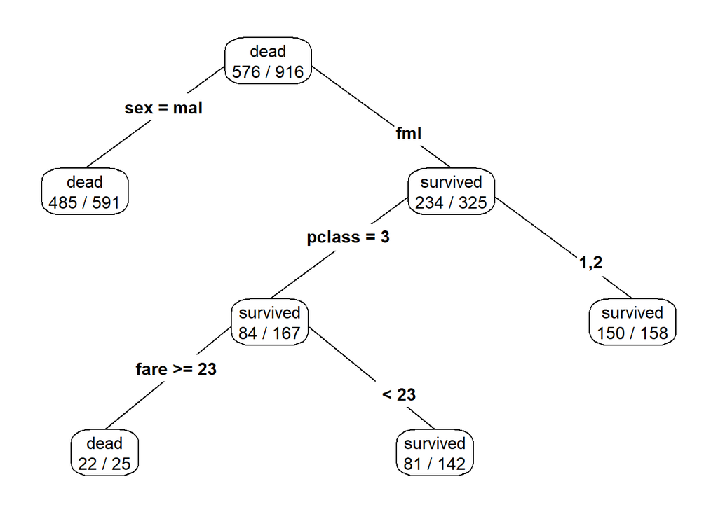

```r
prp(tree.fit,type=4,extra = 2)
```

```r
pred_tree<-predict(tree.fit,titan_test[,-2],type='prob')
head(pred_tree)
```

```
##          dead  survived
## 1  0.05063291 0.9493671
## 3  0.05063291 0.9493671
## 5  0.05063291 0.9493671
## 9  0.05063291 0.9493671
## 13 0.05063291 0.9493671
## 25 0.05063291 0.9493671
```

#### 의사결정나무 - 성과분석

```r
pred_tree2<-predict(tree.fit,titan_test[,-2],type='class')
confusionMatrix(data=pred_tree2,reference=titan_test[,2],positive="survived")
```

```
## Confusion Matrix and Statistics
##
##           Reference
## Prediction dead survived
##   dead      205       55
##   survived   28      105
##
##                Accuracy : 0.7888
##                  95% CI : (0.7451, 0.8281)
##     No Information Rate : 0.5929
##     P-Value [Acc > NIR] : < 2.2e-16
##
##                   Kappa : 0.5506
##
##  Mcnemar's Test P-Value : 0.004319
##
##             Sensitivity : 0.6562
##             Specificity : 0.8798
##          Pos Pred Value : 0.7895
##          Neg Pred Value : 0.7885
##              Prevalence : 0.4071
##          Detection Rate : 0.2672
##    Detection Prevalence : 0.3384
##       Balanced Accuracy : 0.7680
##
##        'Positive' Class : survived
##
```

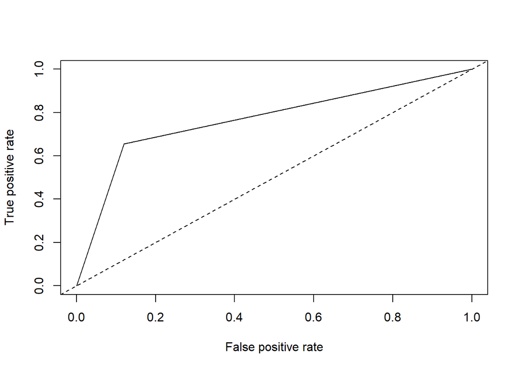

```r
pred.dt.roc<-prediction(as.numeric(pred_tree2),as.numeric(titan_test[,2]))
plot(performance(pred.dt.roc,"tpr","fpr"))
abline(a=0,b=1,lty=2,col="black")
```

```r
performance(pred.dt.roc,"auc")@y.values
```

```
## [[1]]
## [1] 0.7680392
```

### 랜덤포레스트

```r
rf.fit<-randomForest(survived~.,data=titan_train)
rf.fit
```

```
##
## Call:
##  randomForest(formula = survived ~ ., data = titan_train)
##                Type of random forest: classification
##                      Number of trees: 500
## No. of variables tried at each split: 2
##
##         OOB estimate of  error rate: 19.65%
## Confusion matrix:
##          dead survived class.error
## dead      517       59   0.1024306
## survived  121      219   0.3558824
```

```r
pred_rf<-predict(rf.fit, titan_test[,-2],type='prob')
head(pred_rf)
```

```
##     dead survived
## 1  0.106    0.894
## 3  0.014    0.986
## 5  0.014    0.986
## 9  0.038    0.962
## 13 0.036    0.964
## 25 0.216    0.784
```

#### 랜덤포레스트 - 성과분석

```r
pred_rf2<-predict(rf.fit,titan_test[,-2],type='class')
confusionMatrix(data=pred_rf2,reference=titan_test[,2],positive="survived")
```

```
## Confusion Matrix and Statistics
##
##           Reference
## Prediction dead survived
##   dead      212       62
##   survived   21       98
##
##                Accuracy : 0.7888
##                  95% CI : (0.7451, 0.8281)
##     No Information Rate : 0.5929
##     P-Value [Acc > NIR] : < 2.2e-16
##
##                   Kappa : 0.5442
##
##  Mcnemar's Test P-Value : 1.131e-05
##
##             Sensitivity : 0.6125
##             Specificity : 0.9099
##          Pos Pred Value : 0.8235
##          Neg Pred Value : 0.7737
##              Prevalence : 0.4071
##          Detection Rate : 0.2494
##    Detection Prevalence : 0.3028
##       Balanced Accuracy : 0.7612
##
##        'Positive' Class : survived
##
```

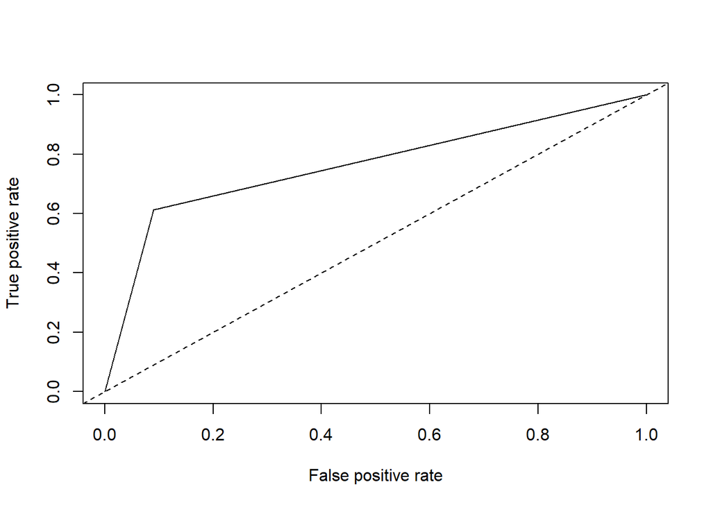

```r
pred.rf.roc<-prediction(as.numeric(pred_rf2),as.numeric(titan_test[,2]))
plot(performance(pred.rf.roc,"tpr","fpr"))
abline(a=0,b=1,lty=2,col="black")
```

```r
performance(pred.rf.roc,"auc")@y.values
```

```
## [[1]]
## [1] 0.7611856
```

### 나이브베이즈

```r
nv.fit<-naiveBayes(survived~.,data=titan_train)
nv.fit
```

```
##
## Naive Bayes Classifier for Discrete Predictors
##
## Call:
## naiveBayes.default(x = X, y = Y, laplace = laplace)
##
## A-priori probabilities:
## Y
##     dead survived
## 0.628821 0.371179
##
## Conditional probabilities:
##           pclass
## Y                  1         2         3
##   dead     0.1614583 0.1840278 0.6545139
##   survived 0.3911765 0.2176471 0.3911765
##
##           sex
## Y             female      male
##   dead     0.1579861 0.8420139
##   survived 0.6882353 0.3117647
##
##           sibsp
## Y               [,1]      [,2]
##   dead     0.5243056 1.2084195
##   survived 0.4823529 0.7058419
##
##           parch
## Y               [,1]      [,2]
##   dead     0.3350694 0.9457747
##   survived 0.4970588 0.8110539
##
##           fare
## Y              [,1]     [,2]
##   dead     24.60935 37.56761
##   survived 47.66230 68.22689
##
##           embarked
## Y                  C         Q         S
##   dead     0.1527778 0.1076389 0.7395833
##   survived 0.2823529 0.1058824 0.6117647
```

```r
pred_nv<-predict(nv.fit, titan_test[,-2],type='raw')
head(pred_nv)
```

```
##              dead  survived
## [1,] 1.764529e-05 0.9999824
## [2,] 2.664938e-03 0.9973351
## [3,] 2.664938e-03 0.9973351
## [4,] 4.261475e-01 0.5738525
## [5,] 5.063860e-02 0.9493614
## [6,] 6.228935e-06 0.9999938
```

#### 나이브베이즈 성과분석

```r
pred_nv2<-predict(nv.fit,titan_test[,-2],type='class')
confusionMatrix(data=pred_nv2,reference=titan_test[,2],positive="survived")
```

```
## Confusion Matrix and Statistics
##
##           Reference
## Prediction dead survived
##   dead      209       57
##   survived   24      103
##
##                Accuracy : 0.7939
##                  95% CI : (0.7505, 0.8328)
##     No Information Rate : 0.5929
##     P-Value [Acc > NIR] : < 2.2e-16
##
##                   Kappa : 0.5588
##
##  Mcnemar's Test P-Value : 0.0003772
##
##             Sensitivity : 0.6438
##             Specificity : 0.8970
##          Pos Pred Value : 0.8110
##          Neg Pred Value : 0.7857
##              Prevalence : 0.4071
##          Detection Rate : 0.2621
##    Detection Prevalence : 0.3232
##       Balanced Accuracy : 0.7704
##
##        'Positive' Class : survived
##
```

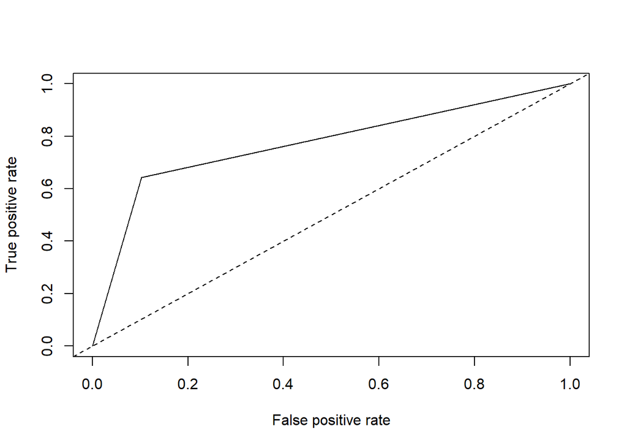

```r
pred.nv.roc<-prediction(as.numeric(pred_nv2),as.numeric(titan_test[,2]))
plot(performance(pred.nv.roc,"tpr","fpr"))
abline(a=0,b=1,lty=2,col="black")
```

```r
performance(pred.nv.roc,"auc")@y.values
```

```
## [[1]]
## [1] 0.7703729
```

## 텍스트 마이닝

```r
clean_txt<-function(txt){
  txt<-tolower(txt)             # 대, 소문자 변환
  txt<-removePunctuation(txt)   # 구두점 제거
  txt<-removeNumbers(txt)       # 숫자 제거
  txt<-stripWhitespace(txt)     # 공백제거

  return(txt)
}
moon_1<-clean_txt(moon)

head(moon_1)
```

```
## [1] "존경하고 사랑하는 국민 여러분 감사합니다"
## [2] "국민 여러분의 위대한 선택에 머리 숙여 깊이 감사드립니다 저는 오늘 대한민국 제대 대통령으로서 새로운 대한민국을 향해 첫걸음을 내딛습니다 지금 제 두 어깨는 국민 여러분으로부터 부여받은 막중한 소명감으로 무겁습니다 지금 제 가슴은 한번도 경험하지 못한 나라를 만들겠다는 열정으로 뜨겁습니다 그리고 지금 제 머리는 통합과 공존의 새로운 세상을 열어갈 청사진으로 가득 차 있습니다"
## [3] ""
## [4] "우리가 만들어가려는 새로운 대한민국은 숱한 좌절과 패배에도 불구하고 우리의 선대들이 일관되게 추구했던 나라입니다 또 많은 희생과 헌신을 감내하며 우리 젊은이들이 그토록 이루고 싶어 했던 나라입니다 그런 대한민국을 만들기 위해 저는 역사와 국민 앞에 두렵지만 겸허한 마음으로 대한민국 제대 대통령으로서의 책임과 소명을 다할 것임을 천명합니다"
## [5] ""
## [6] "함께 선거를 치른 후보들께 감사의 말씀과 심심한 위로를 전합니다 이번 선거에서는 승자도 패자도 없습니다 우리는 새로운 대한민국을 함께 이끌어가야 할 동반자입니다 이제 치열했던 경쟁의 순간을 뒤로하고 함께 손을 맞잡고 앞으로 전진해야 합니다"
```

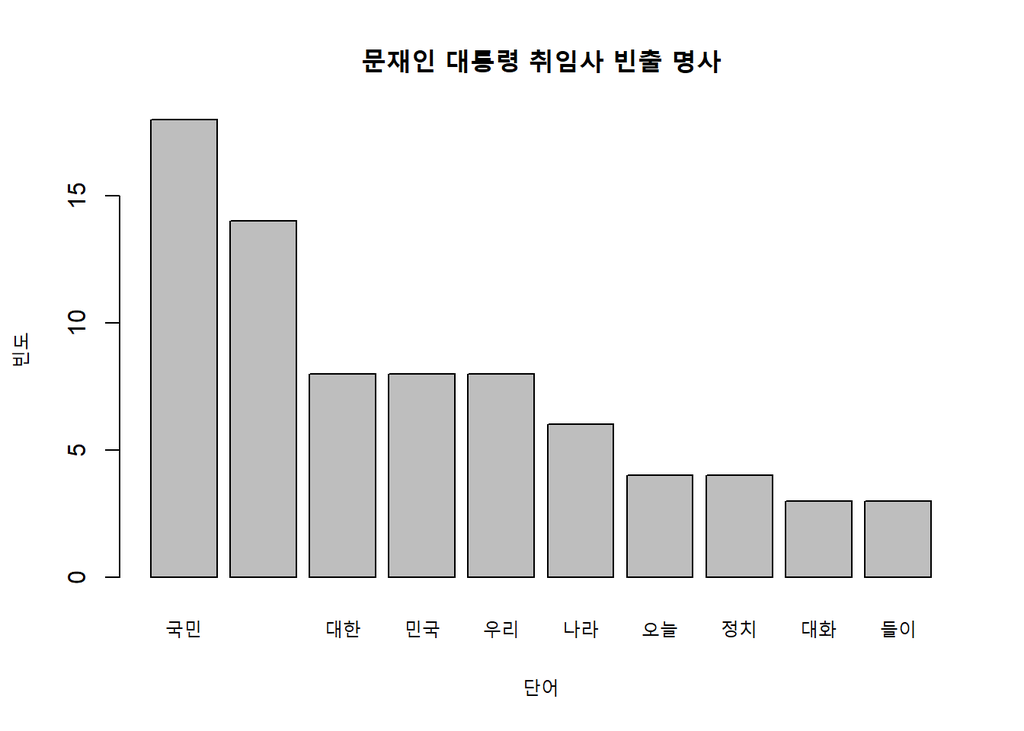

```r
moon_1<-clean_txt(moon)

noun<-extractNoun(moon_1)                   #명사 추출
wordcount<-table(unlist(noun))
cnoun<-as.data.frame(wordcount, stringsAsFactors = F)

table.cnoun<-cnoun[nchar(cnoun$Var1)>=2,]   #단어 길이가 2 이상만 추출

top_10<-table.cnoun %>% arrange(-Freq) %>% head(10)

barplot(top_10$Freq,names=top_10$Var1, main="문재인 대통령 취임사 빈출 명사",
        xlab="단어",
        ylab="빈도")
```

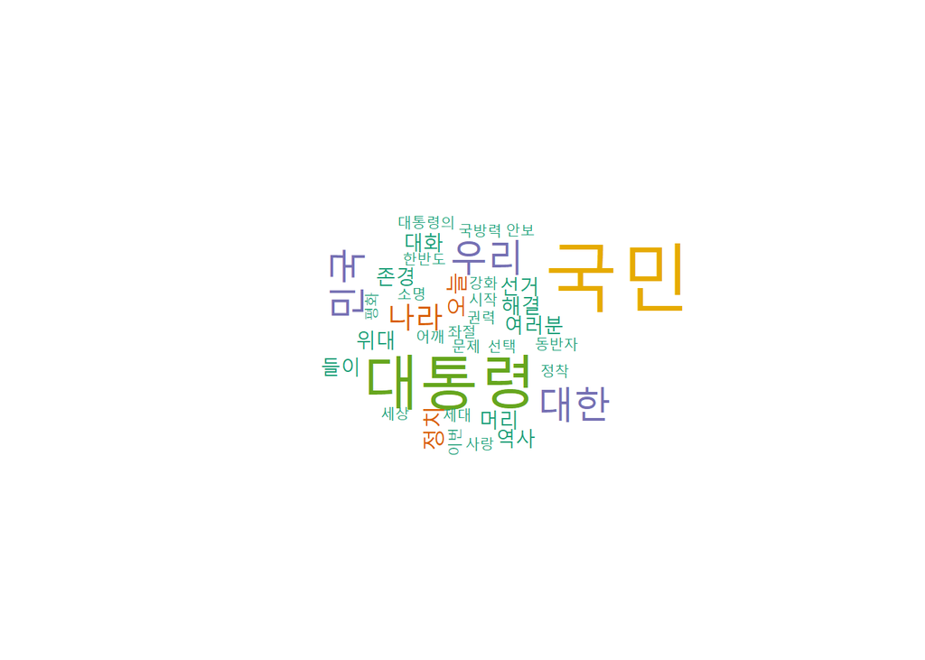

```r
result<-table.cnoun %>% arrange(-Freq)

t<-wordcloud(result$Var1,result$Freq,color=brewer.pal(6,"Dark2"),min.freq=2)
```